# In Class Exercise 6

In this in class exercise, I will explore using sf, tidyverse and tmap packages on sample data to practice handling, processing, visualising and analysing movement and geospatial data.

Jeremiah Lam https://sg.linkedin.com/in/jeremiah-lam-6156238a (School of Computing and Information Systems)https://scis.smu.edu.sg/  
2022-05-21

# Getting Started

Before getting started, it is important to ensure that the required R packages have been installed. If yes, we will load the R packages. If they have yet to be installed, we will install the R packages and load them onto R environment.

The chunk code below will do the trick.

```r
packages = c('tidyverse', 'sf', 'tmap', 'clock')

for(p in packages){
  if(!require(p, character.only = T)){
    install.packages(p)
  }
  library(p, character.only = T)
}
```

# Importing Data

The code chunk below imports *Schools.csv* from the data folder into R by using [`read_sf()`](https://r-spatial.github.io/sf/reference/st_read.html) of [**sf**](https://r-spatial.github.io/sf/) package and saves it as a data frame called *schools*. Steps is repeated for *buildings*, *pubs*, *restaurants*, *apartments* and *employers*.

```r
schools <- read_sf("data/Schools.csv",
                   options = "GEOM_POSSIBLE_NAMES=location")

buildings <- read_sf("data/Buildings.csv",
                   options = "GEOM_POSSIBLE_NAMES=location")

pubs <- read_sf("data/Pubs.csv",
                   options = "GEOM_POSSIBLE_NAMES=location")

restaurants <- read_sf("data/Restaurants.csv",
                   options = "GEOM_POSSIBLE_NAMES=location")

apartments <- read_sf("data/Apartments.csv",
                   options = "GEOM_POSSIBLE_NAMES=location")

employers <- read_sf("data/Employers.csv",
                   options = "GEOM_POSSIBLE_NAMES=location")
```

# Review Data

After importing the data file into R, it is important for us to review the data object.

```r
print(schools)
```

```
Simple feature collection with 4 features and 4 fields
Geometry type: POINT
Dimension:     XY
Bounding box:  xmin: -4701.463 ymin: 1607.984 xmax: -376.7505 ymax: 6556.032
CRS:           NA
# A tibble: 4 x 5
  schoolId monthlyCost maxEnrollment             location
  <chr>    <chr>       <chr>                      <POINT>
1 0        12.81244502 242           (-376.7505 1607.984)
2 450      91.14351385 418           (-2597.448 3194.155)
3 900      38.00537955 394           (-2539.158 6556.032)
4 1350     73.19785215 384           (-4701.463 5141.763)
# ... with 1 more variable: buildingId <chr>
```

# Plotting the map

The code chunk below plots the building polygon features by using tm_polygon(). This displays an interactive map plot, it can easily be switched to an static view by changing to `tmap_mode("plot")` instead.

```r
tmap_mode("view")
tm_shape(buildings)+
tm_polygons(col = "grey60",
           size = 1,
           border.col = "black",
           border.lwd = 1)
```

[interactive chart not shown]

```r
tmap_mode("plot")
```

The code chunk below is used to plot a composite map by combining the buildings and employers simple feature data.frames.

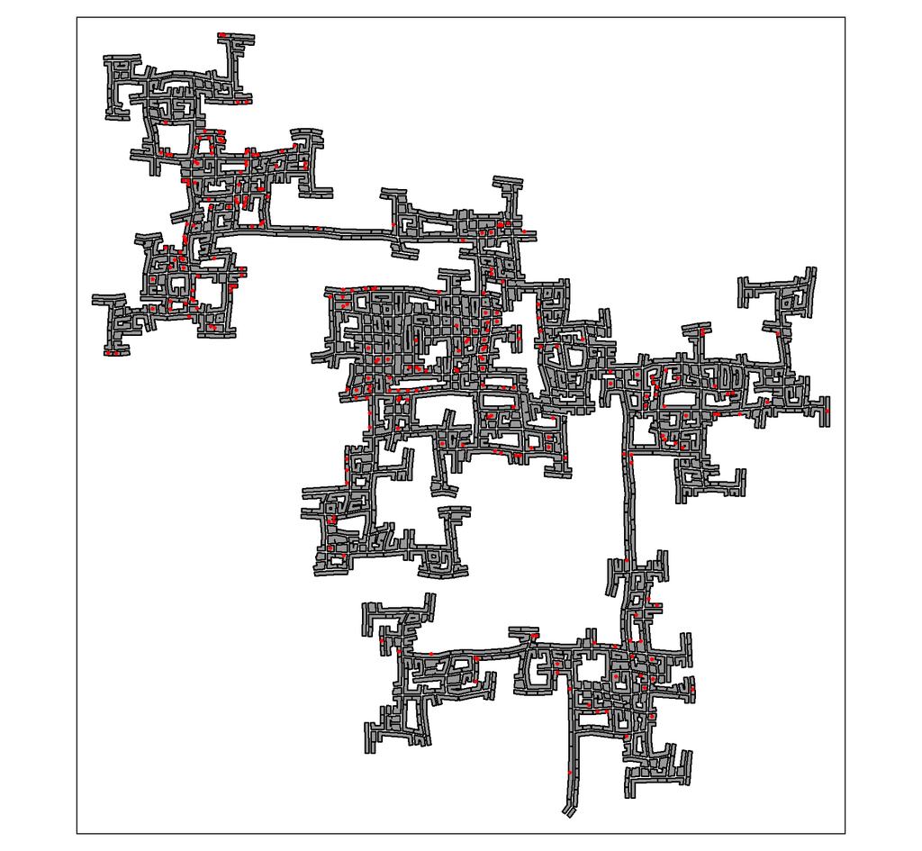

```r
tmap_mode("plot")
tm_shape(buildings)+
tm_polygons(col = "grey60",
           size = 1,
           border.col = "black",
           border.lwd = 1) +
tm_shape(employers) +
  tm_dots(col = "red")
```

# Understanding movement

### Taking in the data

The code chunk below imports *ParticipantStatusLogs1.csv* from the data folder into R by using [`read_sf()`](https://r-spatial.github.io/sf/reference/st_read.html) of [**sf**](https://r-spatial.github.io/sf/) package and saves it as a data frame called *logs*.

```r
logs <- read_sf("data/ParticipantStatusLogs1.csv",
                options = "GEOM_POSSIBLE_NAMES=currentLocation")
```

The code chunk below parses the timestamp field into correct date-time data type using `date_time_parse()` and `get_day()` of clock package.

```r
logs_selected <- logs %>%
  mutate(Timestamp = date_time_parse(timestamp,
                                     zone = "",
                                     format = "%Y-%m-%dT%H:%M:%S"))%>%
  mutate(day = get_day(Timestamp)) %>%
  filter(currentMode == "Transport")
```

### Plotting the movement

The code chunk below is used to plot a composite map by combining the buildings and logs simple feature data.frames.

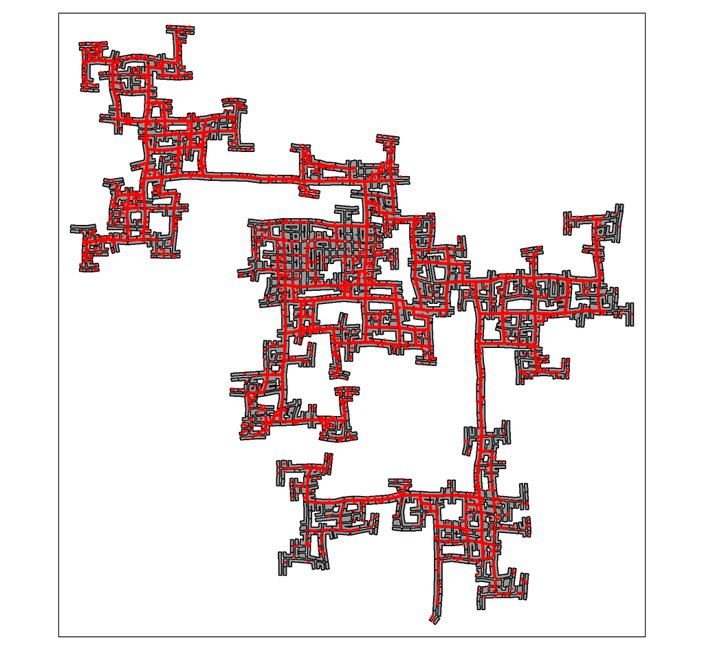

```r
tmap_mode("plot")
tm_shape(buildings)+
tm_polygons(col = "grey60",
           size = 1,
           border.col = "black",
           border.lwd = 1) +
tm_shape(logs_selected) +
  tm_dots(col = "red")
```

### Plotting Using Hexagon Binning Map

The below code chunk is used to create a hexagon to plot the map on.

```r
hex <- st_make_grid(buildings,
                    cellsize=100,
                    square=FALSE) %>%
  st_sf() %>%
  rowid_to_column('hex_id')
```

The code chunk below perform point in polygon overlay by using `[st_join()]` of sf package and count the number of event points in the hexagons.

```r
points_in_hex <- st_join(logs_selected,
                         hex,
                         join=st_within) %>%
  st_set_geometry(NULL) %>%
  count(name='pointCount', hex_id)
head(points_in_hex)
```

```
# A tibble: 6 x 2
  hex_id pointCount
   <int>      <int>
1    169         35
2    212         56
3    225         21
4    226         94
5    227         22
6    228         45
```

In the code chunk below, `left_join()` of dplyr package is used to perform a left-join by using hex as the target table and points_in_hex as the join table. The join ID is hex_id.

```r
hex_combined <- hex %>%
  left_join(points_in_hex,
            by = 'hex_id') %>%
  replace(is.na(.), 0)
```

In the code chunk below, tmap package is used to create the hexagon binning map.

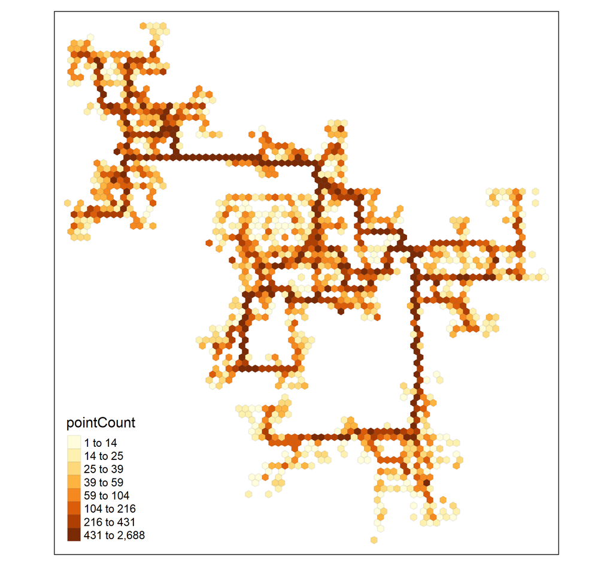

```r
tm_shape(hex_combined %>%
           filter(pointCount > 0))+
  tm_fill("pointCount",
          n = 8,
          style = "quantile") +
  tm_borders(alpha = 0.1)
```

### Plotting Movement Paths

Code chunk below joins the event points into movement paths by using the participants’ IDs as unique identifiers.

```r
logs_path <- logs_selected %>%
  group_by(participantId, day) %>%
  summarize(m = mean(Timestamp),
            do_union=FALSE) %>%
  st_cast("LINESTRING")
```

Code chunk below overplots the GPS path of participant ID = 0 onto the background building footprint map

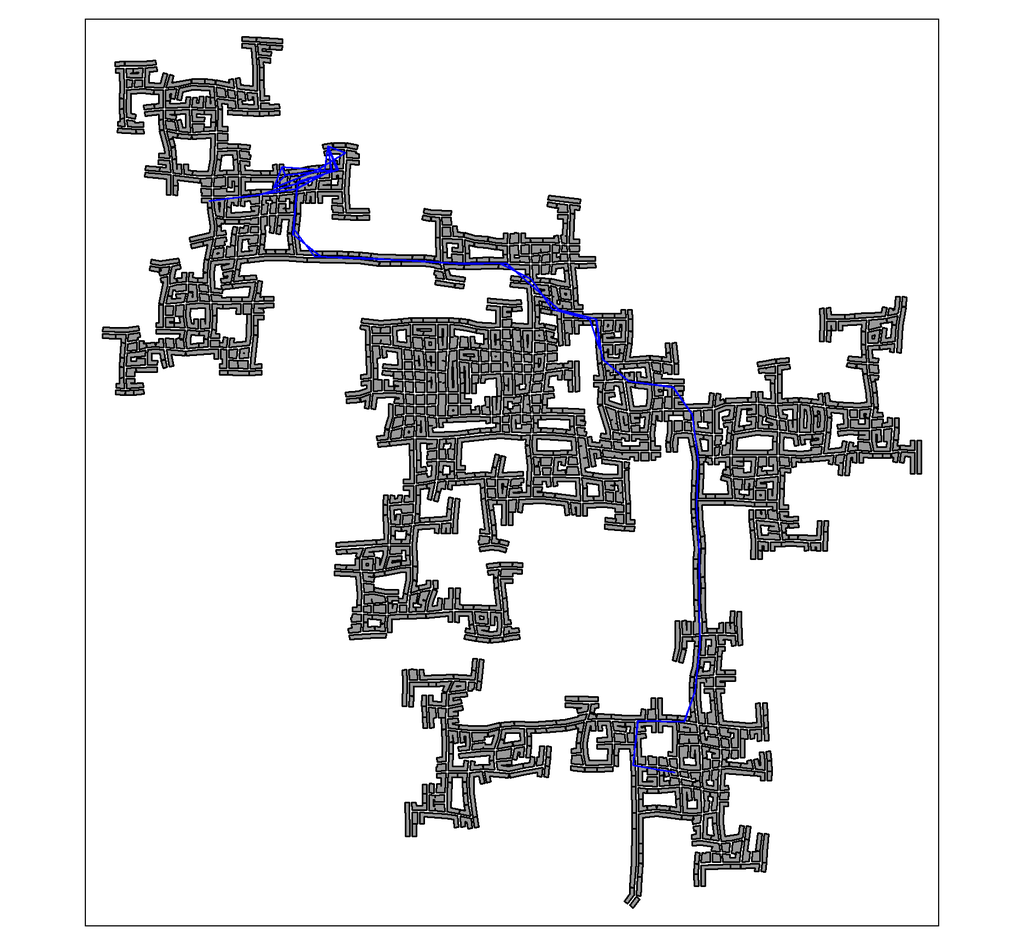

```r
logs_path_selected <- logs_path %>%
  filter(participantId == 0)

tmap_mode("plot")
tm_shape(buildings)+
tm_polygons(col = "grey60",
           size = 1,
           border.col = "black",
           border.lwd = 1) +
tm_shape(logs_path_selected) +
  tm_lines(col = "blue")
```